# Lab 6

Aliza Fassler

10/13/2021

I worked with Sonja Glasser and Justin Roch.

# **Q1 (3 pts.): Show the R code you used to define your sse_mean() function. Include the following line before your function definition:**

```r
rm(list = ls())
sse_mean = function(x)
 {
  y = na.omit(x)
  return(sd(y)/sqrt(length(y)))
}

sse_mean(penguins$bill_depth_mm)
```

```
## [1] 0.1067846
```

```r
sse_mean(mtcars$mpg)
```

```
## [1] 1.065424
```

#This is also an option

```r
rm(list = ls())
sse_mean2 = function(x)
 {
  y = x[is.na(x) != 1]
  return(sd(y)/sqrt(length(y)))
}

sse_mean2(penguins$bill_depth_mm)
```

```
## [1] 0.1067846
```

```r
sse_mean2(mtcars$mpg)
```

```
## [1] 1.065424
```

# **Q2 (4 pts.): Include the code you used to define your two_group_resample() function into the text input.**

```r
x = dat_pen$flipper_length_mm
n_1 = 68
n_2 = 152

two_group_resample = function(x, n_1, n_2)
{
dat_1 = sample(x, n_1, replace = TRUE)
dat_2 = sample(x, n_2, replace = TRUE)

difference_in_means = mean(dat_1, na.rm = TRUE) - mean(dat_2, na.rm = TRUE)

  return(difference_in_means)
}
```

##testing function

```r
set.seed(54321)
two_group_resample(dat_pen$flipper_length_mm, 68, 152)
```

```
## [1] 2.123452
```

# **Q3 (2 pts.): Does your function perform Monte Carlo or bootstrap resampling, i.e. does it simulate a null or an alternative hypothesis? You may want to review your answer after you complete the rest of the lab questions.**

My function performs Monte Carlo function, because it resamples flipper length with no relationship to the species. This simulates the null hypothesis.

# **Q4 (2 pts.): Create histogram of the resampled differences of means**

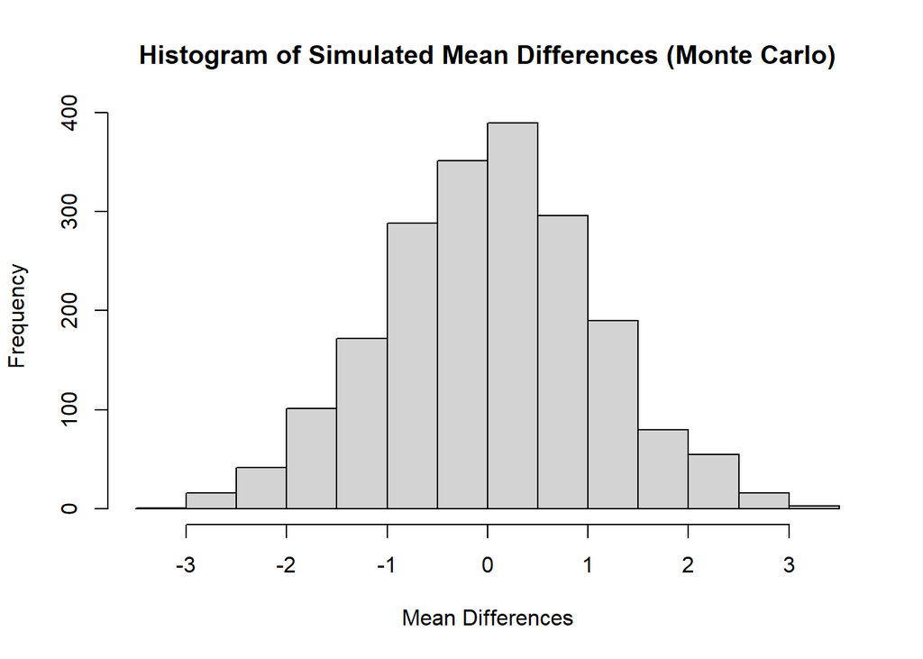

```r
n = 2000
mean_differences = c()
for (i in 1:n)
{
  mean_differences = c(
    mean_differences,
    two_group_resample(dat_pen$flipper_length_mm, 68, 152)
  )
}
hist(mean_differences, main = "Histogram of Simulated Mean Differences (Monte Carlo)", xlab = "Mean Differences")
```

# **Q5 (6 pts.): How many of your resampled differences of means were greater than 5.8?**

None because my sampling method approximated the null hypothesis.

**Assume that we are doing a 2-sided test: we don’t care which species has longer** **flippers, we only want to know if they are different.** **Include the R code you used to check the number of differences greater than 5.8.**

```r
t_test = t.test(dat_pen$flipper_length_mm ~ dat_pen$species)
t_test
```

```
##
##  Welch Two Sample t-test
##
## data:  dat_pen$flipper_length_mm by dat_pen$species
## t = -5.7804, df = 119.68, p-value = 6.049e-08
## alternative hypothesis: true difference in means is not equal to 0
## 95 percent confidence interval:
##  -7.880530 -3.859244
## sample estimates:
##    mean in group Adelie mean in group Chinstrap
##                189.9536                195.8235
```

```r
diff_observed = round(diff(t_test$estimate), digits = 3)
print(diff_observed, digits = 3)
```

```
## mean in group Chinstrap
##                    5.87
```

```r
sum(abs(mean_differences) >= diff_observed)
```

```
## [1] 0
```

# **Q6 (2 pts.): Given a p value of less than 1 per 10 million, how many simulations do you think you would have to do to see a difference in mean flipper length equal to or greater than 5.8 mm?**

Over 10 million, because a p-value that small indicates that we would be extremely unlikley to to see that pattern if we re-sampled due to chance alone.

# **Q7 (1 pt.): Include a boxplot of your chosen variable in your report.**

#boxplot

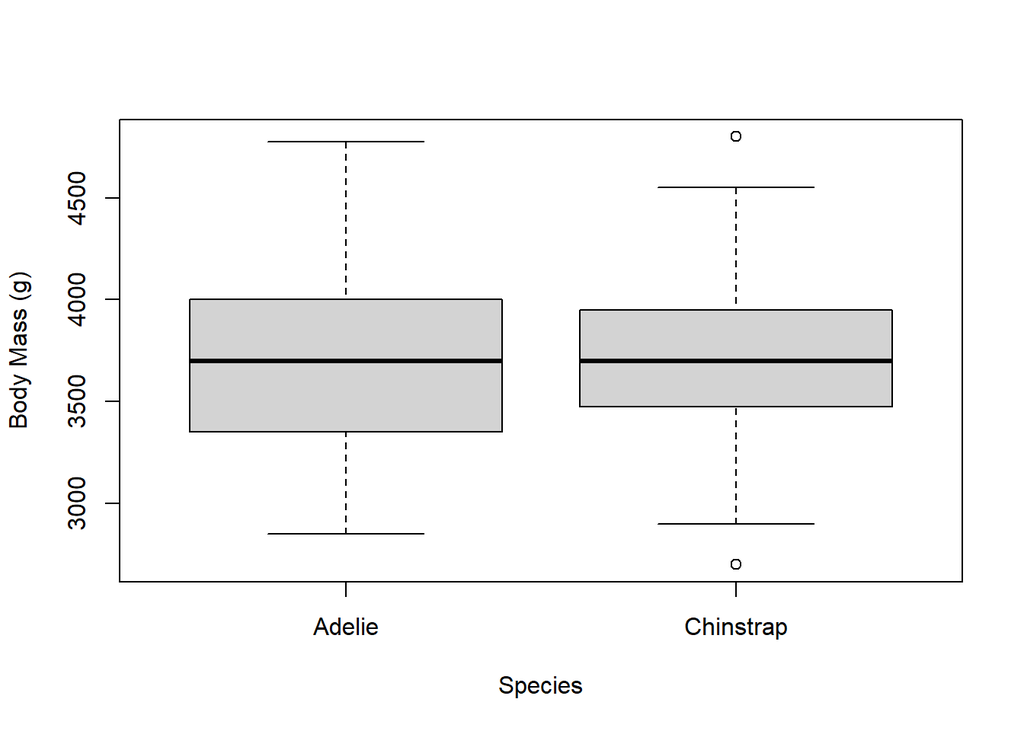

```r
boxplot(dat_pen$body_mass_g ~ dat_pen$species, xlab = "Species", ylab = "Body Mass (g)")
```

# **Q8 (3 pts.): Report the group means and difference between the means.**

#aggregate

```r
agg_means = aggregate(
  body_mass_g ~ species,
  data = dat_pen,
  FUN = mean,
  na.rm = TRUE)
diff_observed = diff(agg_means[, 2])

agg_means
```

```
##     species body_mass_g
## 1    Adelie    3700.662
## 2 Chinstrap    3733.088
```

```r
diff_crit = diff_observed
diff_crit
```

```
## [1] 32.42598
```

The Adelie group mean = 3700.662, the Chinstrap group mean = 3733.088. The difference between the means is 32.4259g.

# **Q9 (4 pts.): Interpret the p-value from the t-test output in plain, non-technical English that a non-statistician would understand.**

The p-value from the t-test shows that it is very likely we would observe a difference in mean body mass of 32.4259g by chance alone (i.e. because of random individual variation in our sample). If were were to re-sample this population repeatedly our random samples would have over a 50% chance of seeing this great a difference in means or greater.

```r
t_test = t.test(dat_pen$body_mass_g ~ dat_pen$species)
t_test
```

```
##
##  Welch Two Sample t-test
##
## data:  dat_pen$body_mass_g by dat_pen$species
## t = -0.54309, df = 152.45, p-value = 0.5879
## alternative hypothesis: true difference in means is not equal to 0
## 95 percent confidence interval:
##  -150.38481   85.53284
## sample estimates:
##    mean in group Adelie mean in group Chinstrap
##                3700.662                3733.088
```

# **Q10 (2 pts.): How many differences in means were greater than diff_crit?**

**Remember to treat this as a 2-tailed test.**

```r
n = 1000
mean_differences = c()
for (i in 1:n)
{
  mean_differences = c(
    mean_differences,
    two_group_resample(dat_pen$body_mass_g, 68, 152)
  )
}
sum(abs(mean_differences) >= diff_observed)
```

```
## [1] 614
```

# **Q11 (2 pts.): Include a histogram of your simulation results in your report. Make sure it has appropriate title and labels.**

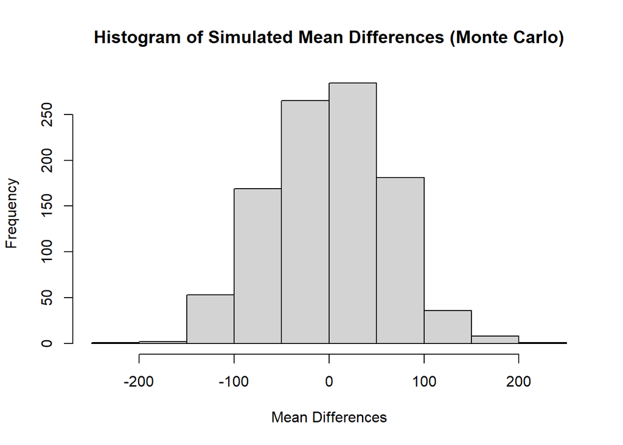

```r
hist(mean_differences, main = "Histogram of Simulated Mean Differences (Monte Carlo)", xlab = "Mean Differences")
```